# 4058 Final Project

Pranjal Bajaj & Padraig Mark

12/6/2017

## Introduction

Here we decide to investigate one of the most useful applications of machine learning techniques - whether credit card fraud has taken place on transactions or not. This is an important question for credit card companies for a number of reasons; one being that if a company were to be seen as prone to credit card theft then this would result in both the demise of its image as a credible and trustworthy company as well as perhaps an increase in fraudulent activity by fraudsters who deem the company as an ‘easy target’. As such, it is becoming very important, in an ever more competitive market, for credit card companies to be able to accurately and efficiently detect instances of credit card fraud.

Once a company detects what it seems to be fraudulent activity it can follow to main paths. Either a company can automatically block the transaction from happening or it can decide to follow up on the claim by calling, texting or emailing the customer who has potenially been defrauded. There are obvious costs to the credit card company with both these actions. In terms of automatically blocking transactions - customers can become fraustrated if credit card companies are blocking legitmate transactions that are thought to be fraudulent; this an example of the credit card company exhibiting bad customer experience. In terms of of following up with individuals on whether a transaction on their card was made by them or not - the costs associated to the credit card company are mostly one of the time and monetary costs to calling, emailing etc customers to check if they were the ones to make purchases. Therefore, it is in the interest of credit card companies to limit the number of false negatives (those are transaction they preidct to not be fraudulent but are actually instances of fraud) and false positives (predictions that are a transaction is fraudulent when in actual fact it is not).

Therefore, in this investigate we will be trying to classify whether transactions are fraudulent or not.

```r
library(readr)

cc_fraud <- read.csv("creditcard.csv")

cc_fraud$Class <- as.factor(cc_fraud$Class)
```

In this investigation ‘Class’ is our outcome variable where it is coded as 0 if a transaction is not fraudulent and 1 if the transaction is fraudulent. Due to sensitivity, the predictors of interest are labelled V1 - V28, where they are the first 28 principle components of a large number of predictors of credit card fraud. We will be using these 28 prinicple components as well as the amount of the transaction to predict whether a transaction is fraudulent or not.

# Data Inspection

```r
dim(cc_fraud) # Data Dimensions
```

```
## [1] 284807     31
```

284807 observations. 31 Variables (including the Class Variable).

```r
head(cc_fraud) # First 6 rows
```

```
##   Time         V1          V2        V3         V4          V5          V6
## 1    0 -1.3598071 -0.07278117 2.5363467  1.3781552 -0.33832077  0.46238778
## 2    0  1.1918571  0.26615071 0.1664801  0.4481541  0.06001765 -0.08236081
## 3    1 -1.3583541 -1.34016307 1.7732093  0.3797796 -0.50319813  1.80049938
## 4    1 -0.9662717 -0.18522601 1.7929933 -0.8632913 -0.01030888  1.24720317
## 5    2 -1.1582331  0.87773676 1.5487178  0.4030339 -0.40719338  0.09592146
## 6    2 -0.4259659  0.96052304 1.1411093 -0.1682521  0.42098688 -0.02972755
##            V7          V8         V9         V10        V11         V12
## 1  0.23959855  0.09869790  0.3637870  0.09079417 -0.5515995 -0.61780086
## 2 -0.07880298  0.08510165 -0.2554251 -0.16697441  1.6127267  1.06523531
## 3  0.79146096  0.24767579 -1.5146543  0.20764287  0.6245015  0.06608369
## 4  0.23760894  0.37743587 -1.3870241 -0.05495192 -0.2264873  0.17822823
## 5  0.59294075 -0.27053268  0.8177393  0.75307443 -0.8228429  0.53819555
## 6  0.47620095  0.26031433 -0.5686714 -0.37140720  1.3412620  0.35989384
##          V13        V14        V15        V16         V17         V18
```

[output cut: 20 more lines]

We see that all but two features have Principal Component Analysis (PCA) scores associated. These scores are normalised/standardised i.e. mean 0 and standard deviation equal to 1. The two featues that aren’t normalised are:

- Time
- Amount

We may need to normalise them depending on the approach we use and processing time. Regardless, it is important to keep note of this.

Ranges of these two variables:

```r
range(cc_fraud$Amount)
```

```
## [1]     0.00 25691.16
```

```r
range(cc_fraud$Time)
```

```
## [1]      0 172792
```

Checking if data has any missing values:

```r
is.na(cc_fraud) #FALSE for the entire dataset i.e. no missing values.
```

```r
table(cc_fraud$Class)
```

```
##
##      0      1
## 284315    492
```

```r
prop.table(table(cc_fraud$Class))
```

```
##
##           0           1
## 0.998272514 0.001727486
```

# Exploratory Data Analysis and Visualisation

## Correlation Matrix Plot

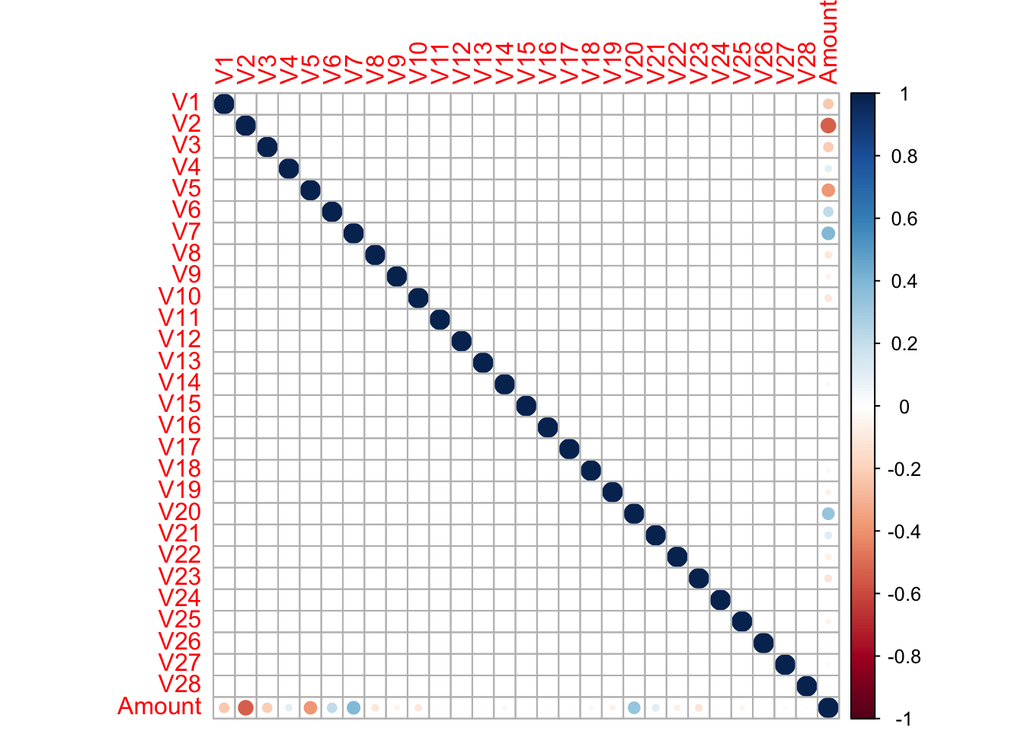

```r
library(corrplot)
cor.dat <- cc_fraud[, -c(1,31)]

corrplot(cor(cor.dat))
```

This plot shows us a visualisation of the correlation matrix. The diagonal elements indicated by the dark blue dots show the correlation of the variables with themselves and hence are dark blue as they are perfectly correlated to themselves.

# Modelling and Predicting

## Splitting Data into Test and Train

Here we assign 75% of our data to the training set and the remaining to our testing set.

We drop the time variable from our training and testing dataset because of erroros associated with including it in our later models.

```r
library(caret)
set.seed(9598)

in_train <- createDataPartition(y = cc_fraud$Class,
                                p = 3 / 4, list = FALSE) #75% train data #25% test data

training <- cc_fraud[ in_train, ]
testing  <- cc_fraud[-in_train, ]

# Dropping time variable
training <- training[, -1]
testing <- testing [, -1]
```

```r
table(training$Class)
```

```
##
##      0      1
## 213237    369
```

```r
table(testing$Class)
```

```
##
##     0     1
## 71078   123
```

Here, the training data set has 369 Frauds and the testing data set has 123 Frauds.

## Baseline: Logit Model

We begin with a simple logit model. The idea is to get a sense of the predictive power of our model.

```r
# Run the logit model
logit <- glm(Class ~ ., data = training, family = binomial(link = "logit"))
# Run predictions
y_hat_logit <- predict(logit, newdata = testing, type = "response")

# Assign classes
z_logit <- as.integer(y_hat_logit > 0.15)

# Create the confusion matrix
(t_log <- table(testing$Class, z_logit))
```

```
##    z_logit
##         0     1
##   0 71046    32
##   1    28    95
```

```r
sum(diag(t_log)) / sum(t_log)
```

```
## [1] 0.9991573
```

We notice that an accuracy score of: 0.9991573.

Despite so many false positives and false negatives, our accuracy score is very high. This is because we only have 0.173% frauds in our data i.e. our data is highly imbalanced. Hence, we will need to use other approaches to measure our accuracy. We will rely on Area Under the Precision-Recall Curve (AUPRC).

Precision Score: The measure of correctness achieved in positive prediction i.e. of observations labeled as positive, how many are actually labeled positive.

```r
precision_logit <- 95 / (95+ 28)
precision_logit
```

```
## [1] 0.7723577
```

Looking at the Recall Score:

```r
recall_logit <- 95 / (95 + 32)
recall_logit
```

```
## [1] 0.7480315
```

Now calculaitng the Area Under the Precision-Recall Curve (AUPRC) we find:

```r
library(ROSE)
```

```r
roc.curve(testing$Class, z_logit, plotit = FALSE)
```

```
## Area under the curve (AUC): 0.886
```

## Approaches to Improve Accuracy

In order to cure imbalances in our data, four traditional approaches are available:

1. Undersample the majority class: Two ways ->
1. Random: Randomly chooses observations from majority class which are eliminated until the data set gets balanced
2. Informative: Two ways ->
- EasyEnsemble: At first, it extracts several subsets of independent sample (with replacement) from majority class. Then, it develops multiple classifiers based on combination of each subset with minority class. Works like an unsupervised learning algorithm.
- BalanceCascade: It takes a supervised learning approach where it develops an ensemble of classifier and systematically selects which majority class to ensemble.
2. Oversample the minorty class: It replicates the observations from minority class to balance the data. Two ways:
1. Random oversampling balances the data by randomly oversampling the minority class.
2. Informative oversampling uses a pre-specified criterion and synthetically generates minority class observations.
3. Synthetic Data Generation: Generates artificial data to balance the class imbalance.
4. Cost Sensitive Learning (CSL): This method evaluates the cost associated with misclassifying observations.

For our dataset, we will be using the undersampling approach, this method is best to use when the data set is huge and reducing the number of training samples helps to improve run time and storage troubles. However, to show results with a possible counterfactual, we also demonstrate Syntehtic Data Generation.

### Undersampling Majority Class:

```r
undersampled_data <- ovun.sample(Class ~ ., data = training, method = "under", N = 5000, seed = 12345)$data
table(undersampled_data$Class)
```

```
##
##    0    1
## 4631  369
```

### Synthetic Data Generation:

```r
synth_data <- ROSE(Class ~ ., data = training, seed = 123467)$data
table(synth_data$Class)
```

```
##
##      0      1
## 106268 107338
```

As can be seen synthetic data generation creates a large number of random observations for the training dataset.

### Running the logit on the new data:

#### 1. Undersampled Data:

```r
# Run the logit model
logit_undersampled <- glm(Class ~ ., data = undersampled_data, family = binomial(link = "logit"))
# Run predictions
y_hat_logit_undersampled <- predict(logit_undersampled, newdata = testing, type = "response")

# Assign classes
z_logit_undersampled <- as.integer(y_hat_logit_undersampled > 0.15)

# Create the confusion matrix
(t_log_undersampled <- table(testing$Class, z_logit_undersampled))
```

```
##    z_logit_undersampled
##         0     1
##   0 70387   691
##   1    12   111
```

```r
# Predicting using the Area Under the Precision-Recall Curve (AUPRC)
roc.curve(testing$Class, z_logit_undersampled, plotit = FALSE)
```

```
## Area under the curve (AUC): 0.946
```

#### 2. Synthetically Generated Data (SGD):

```r
# Run the logit model
logit_synthdata <- glm(Class ~ ., data = synth_data, family = binomial(link = "logit"))
# Run predictions
y_hat_logit_synthdata <- predict(logit_synthdata, newdata = testing, type = "response") #drop the first column in testing

# Assign classes
z_logit_synthdata <- as.integer(y_hat_logit_synthdata > 0.15)

# Create the confusion matrix
(t_log_synthdata <- table(testing$Class, z_logit_synthdata))
```

```
##    z_logit_synthdata
##         0     1
##   0 56705 14373
##   1     3   120
```

```r
# Predicting using the Area Under the Precision-Recall Curve (AUPRC)
roc.curve(testing$Class, z_logit_synthdata, plotit = FALSE)
```

```
## Area under the curve (AUC): 0.887
```

Again using this adapted training dataset we achieve an AUPRC score that is better than that of our first logit model with the unadpated data. However, this SDG method has produced a result that is only better than that of our original model (88.7% compared to 88.6%).

In addition, it would be unsustainable for a credit card company to either prevent or investigate over 14,000 claims in order to find 120 instances of credit card fraud. It would be uneconomical for the company.

As a result, going forward, we will be using the undersampled data: - Given our large dataset, undersampling allows us to run our programs much faster with better accuracy.

Disadvantages: - We lose important information regarding the data by dropping lots of the observations while undersampling, however, we hope the fact that observations are dropped randomly will not affect our outcomes too negatively.

## k-Nearest Neighbours

### Formatting data for kNN:

```r
training_knn <- undersampled_data[, -ncol(undersampled_data)] #drop the Class column (last column) and drop the Time column (first column)
testing_knn <- testing[,-c(ncol(testing))] #drop the Time column (first column)
Class_train_knn <- as.factor(undersampled_data[,ncol(undersampled_data)])
Class_test_knn <- as.factor(testing[,ncol(testing)])
k <- sqrt(nrow(undersampled_data))
training_knn$Amount <- scale(training_knn$Amount, center = TRUE, scale = TRUE) #Scale Amount Spent using Credit Card
```

```r
library(class)
library(ROSE)
knn_pred <- knn(training_knn, testing_knn, Class_train_knn, k)

#Confusion Matrix
(t_knn <- table(Class_test_knn, knn_pred))
```

```
##               knn_pred
## Class_test_knn     0     1
##              0 71054    24
##              1    57    66
```

```r
#Measuring accuracy using Area under precision-recall curve
roc.curve(testing$Class, knn_pred, plotit = FALSE)
```

```
## Area under the curve (AUC): 0.768
```

Area under precision recall curve: 76.8%. This model is not good for classification at all. The logit, which is our baseline is far better as it gives us an accuracy of 94.6%.

K nearest neighbors do not perform well in high dimensions due to the curse of dimensionality (k observations that are nearest to a given test observation x1 may be very far away from x1 in p-dimensional space when p is large [ An introduction to statistical learning, James/Witten/Hastie/Tibshirani, pages 108-109 ]), leading to a very poor k-nearest-neighbors fit.

## AIC Logit

We now run an AIC on the logit model testing to see if dropping certain variables improves our results.

```r
# Run step function on logit model
AIC_log <- step(logit_undersampled, trace = FALSE)

# Show dropped variables
setdiff(names(coef(logit_undersampled)), names(coef(AIC_log)))
```

```
##  [1] "V2"     "V3"     "V5"     "V7"     "V9"     "V15"    "V17"
##  [8] "V18"    "V19"    "V20"    "V24"    "V25"    "V26"    "V27"
## [15] "V28"    "Amount"
```

We see above the variables that were dropped from the original logit model.

Now we test the outcome:

```r
# Run predictions
y_AIC_log <- predict(AIC_log, newdata = testing, type = "response")

# Assign classes
z_log_AIC <- as.integer(y_AIC_log > 0.15)

# Create the confusion matrix
(t_logA <- table(testing$Class, z_log_AIC))
```

```
##    z_log_AIC
##         0     1
##   0 70420   658
##   1    13   110
```

```r
# AUPRC
roc.curve(testing$Class, z_log_AIC, plotit = F)
```

```
## Area under the curve (AUC): 0.943
```

We find that the AIC model above produces an AUPRC score of 94.3%. This is not an improvement on the 94.6% we predicted using the full set of variables for the logit model.

Therefore, moving forward we decide to include all variables in our model. Firstly, through the data: using all variables produces better results for us than dropping the variables when predicting using the logit model. Secondly, through intuition: the data has already been subsetted and principle componenets chosen. Thus the features identified V1 - V28 should realistically all have strong prediction power in the models.

## BIC

```r
BIC_log <- step(logit_undersampled, trace = FALSE, k = log(nrow(undersampled_data)))
setdiff(names(coef(logit_undersampled)), names(coef(BIC_log)))
```

```
##  [1] "V1"     "V2"     "V3"     "V5"     "V6"     "V7"     "V9"
##  [8] "V11"    "V13"    "V15"    "V17"    "V18"    "V19"    "V20"
## [15] "V21"    "V22"    "V23"    "V24"    "V25"    "V26"    "V27"
## [22] "V28"    "Amount"
```

We can see the variables that BIC decide to drop and also notice that BIC drops some variables that AIC doesn’t drop. BIC does a more thorough clean up of the predictors in the model.

```r
# Run predictions
y_BIC_log <- predict(BIC_log, newdata = testing, type = "response")

# Assign classes
z_logit_BIC <- as.integer(y_BIC_log > 0.15)

# Create the confusion matrix
(t_logB <- table(testing$Class, z_logit_BIC))
```

```
##    z_logit_BIC
##         0     1
##   0 70472   606
##   1    13   110
```

```r
# AUPRC
roc.curve(testing$Class, z_logit_BIC, plotit = F)
```

```
## Area under the curve (AUC): 0.943
```

With an AUPRC score of 94.3%, the BIC method still performs slightly worse than the original logit model which scored 94.6%. With such close similarity and many of the same reasons given with regards to AIC, we decide to stick with the original logit model moving forward.

## Linear Discriminant Analysis (LDA)

We decide to run LDA on our variables in order to check if this model can be improved upon.

```r
library(MASS)

# LDA <- lda(formula(logit_undersampled), data = undersampled_data)

# Set up LDA
LDA <- lda(Class ~ ., data = undersampled_data)

# Create predictions
pred_lda <- predict(LDA, newdata = testing)

z_LDA <- pred_lda$class

# My changes so code can run
roc.curve(testing$Class, z_LDA, plotit = FALSE)
```

```
## Area under the curve (AUC): 0.894
```

```r
# My changes so code can run
(t_LDA <- table(testing$Class, z_LDA))
```

```
##    z_LDA
##         0     1
##   0 71043    35
##   1    26    97
```

```r
sum(diag(t_LDA)) / sum(t_LDA)
```

```
## [1] 0.9991433
```

We find that running the LDA model we obtain an AUPRC score of 89.4%. This is not an improvement on the orignal logit model that we had ran.

### QDA

Since LDA could not produce more accurate results we decide to test if QDA can produce a better model in able to detect card fraud.

```r
# Set up QDA
QDA <- qda(formula(logit_undersampled), data = undersampled_data)

# Make predictions
pred_qda <- predict(QDA, newdata = testing)

# Present classifications
z_QDA <- pred_qda$class
table(testing$Class, z_QDA)
```

```
##    z_QDA
##         0     1
##   0 68459  2619
##   1    13   110
```

```r
# Test
roc.curve(testing$Class, z_QDA, plotit = F)
```

```
## Area under the curve (AUC): 0.929
```

We observe that QDA does indeed improve on our results giving us a score of 92.9% which is better than that achieved by LDA. However, the results are not as accurate as that of the original logit model.

As we can see from the QDA confusion matrix, we are capturng a lot the vast majority of fraudulent activity. However, this comes at the cost of identifying more claims as fraudulent when they are not. Of course, credit card companies will want to espouse the principle of ‘better safe than sorry’ - however, it is efficient to reduce the number of false positives as this would result in lower costs for the credit card company in terms of following up with clients to check whether so and so activity on their card was fraudulent or not.

# glmpath

Moving on, in order to find improvements on our original model, we run a glmpath algorithm.

```r
# Set up of our Model
X <- model.matrix(logit_undersampled)
y <- undersampled_data$Class
new_X <- model.matrix(logit, data = testing)
```

```r
stopifnot(require(glmpath))
# Run glmpath
path1 <- glmpath(X, y == 1, nopenalty.subset = 1,
                 family = binomial(link = "logit"))
summary(path1)
```

```
## Call:
## glmpath(x = X, y = y == 1, nopenalty.subset = 1, family = binomial(link = "logit"))
```

```
##         Df  Deviance       AIC       BIC
## Step 1   2 2633.5927 2637.5927 2650.6271
## Step 3   3 1345.6800 1351.6800 1371.2316
## Step 6   4 1281.5763 1289.5763 1315.6451
## Step 9   5 1178.9583 1188.9583 1221.5443
## Step 10  6  752.3928  764.3928  803.4960
## Step 11  7  663.3939  677.3939  723.0143
## Step 12  8  644.3512  660.3512  712.4888
## Step 13  9  637.6302  655.6302  714.2849
## Step 16 10  618.3875  638.3875  703.5595
## Step 17 11  598.3198  620.3198  692.0089
## Step 18 12  596.5732  620.5732  698.7795
## Step 19 13  580.1499  606.1499  690.8734
## Step 20 14  578.1223  606.1223  697.3631
## Step 21 15  578.1077  608.1077  705.8656
## Step 23 16  577.1679  609.1679  713.4430
## Step 24 17  570.8506  604.8506  715.6429
## Step 25 18  568.9446  604.9446  722.2541
## Step 28 19  567.4264  605.4264  729.2531
## Step 29 20  566.7605  606.7605  737.1044
## Step 32 21  563.1749  605.1749  742.0360
## Step 34 22  561.8603  605.8603  749.2386
## Step 35 23  561.8295  607.8295  757.7249
## Step 37 24  561.3513  609.3513  765.7639
## Step 40 25  559.9952  609.9952  772.9250
## Step 41 26  559.6064  611.6064  781.0534
## Step 42 26  550.6222  602.6222  772.0692
## Step 43 26  550.6222  602.6222  772.0692
## Step 44 27  550.3949  604.3949  780.3591
## Step 45 28  548.3730  604.3730  786.8544
## Step 46 29  547.8969  605.8969  794.8955
## Step 53 30  547.4761  607.4761  802.9919
## Step 54 31  547.3647  609.3647  811.3977
```

```r
# We identify that the step which gives us the lowest AIC score is step 42
min(path1$aic)
```

```
## [1] 602.6222
```

```r
# Run the predictions with step 42
y_hat_path1 <- predict(path1, newx = new_X, type = "response",
                       s = 42)

z_path1 <- as.integer(y_hat_path1 > 0.15)
table(testing$Class, z_path1)
```

```
##    z_path1
##         0     1
##   0 70413   665
##   1    12   111
```

```r
# AUPRC
roc.curve(testing$Class, z_path1, plotit = F)
```

```
## Area under the curve (AUC): 0.947
```

So far, the glmpath algorithm is the only one which comes close to our original logit model.

## Decision Trees

We decide to also investigate decision trees in order to test if we could obtain better predictions of fraudulent actviity than what we could achieve under our best logit model.

We begin with a simple tree method.

```r
library(tree)

# Run the tree function
out <- tree(Class ~. , data = undersampled_data)
summary(out)
```

```
##
## Classification tree:
## tree(formula = Class ~ ., data = undersampled_data)
## Variables actually used in tree construction:
## [1] "V14" "V7"  "V17" "V4"
## Number of terminal nodes:  6
## Residual mean deviance:  0.1161 = 579.6 / 4994
## Misclassification error rate: 0.0136 = 68 / 5000
```

```r
# Run predictions
y_hat_tree <- predict(out, newdata = testing, type = "class")

# Create classifications
z_tree <- as.integer(y_hat_tree)

# Create the confusion matrix
(t_tree <- table(testing$Class, z_tree))
```

```
##    z_tree
##         1     2
##   0 70805   273
##   1    18   105
```

```r
roc.curve(testing$Class, z_tree, plotit = F)
```

```
## Area under the curve (AUC): 0.925
```

The results of our tree model are interesting. We obtain an AUPRC score of 92.5%. Although we are letting a little more fraud activity through the algorithm (18 undetected cases of fraud compared to 12 in logit), there are considerbly less observations which are falsely predicted to be fraudulent (273 compared to 691). This implies an efficiency in credit card companies to detect fraud without having to suspect so many cases. Nonetheless, the AUPRC remains lower because there are 6 more cases of fraud that went undetected in the model which turned out to be detrimental.

## Boosting

Since trees initially performed very well, we decide to develop more complex tree methods in order to improve our results.

```r
library(gbm)
boosted <- gbm(Class == "1" ~ ., data = undersampled_data,
               interaction.depth = 4, shrinkage = 0.001,
               n.cores = parallel::detectCores())
```

```
## Distribution not specified, assuming bernoulli ...
```

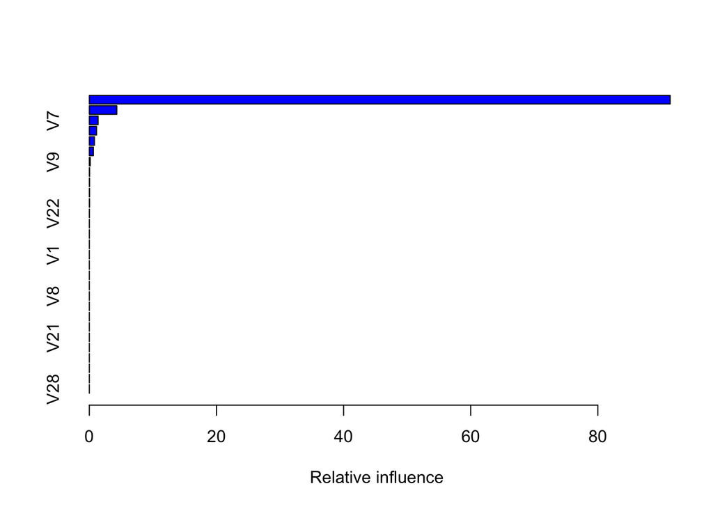

```
##           var      rel.inf
## V14       V14 91.385821430
## V17       V17  4.327821598
## V7         V7  1.375234773
## V12       V12  1.141309078
## V4         V4  0.809112774
## V10       V10  0.638457898
## V9         V9  0.147535802
## Amount Amount  0.042841299
## V11       V11  0.035672212
## V19       V19  0.033630064
## V16       V16  0.032789088
## V22       V22  0.012408074
## V5         V5  0.006517621
## V23       V23  0.005934867
## V20       V20  0.004913422
## V1         V1  0.000000000
## V2         V2  0.000000000
## V3         V3  0.000000000
## V6         V6  0.000000000
## V8         V8  0.000000000
## V13       V13  0.000000000
## V15       V15  0.000000000
## V18       V18  0.000000000
## V21       V21  0.000000000
## V24       V24  0.000000000
## V25       V25  0.000000000
## V26       V26  0.000000000
## V27       V27  0.000000000
## V28       V28  0.000000000
```

```r
summary(boosted)
```

```r
y_boost <- predict(boosted, newdata = testing, type = "response",
                       n.trees = 100)

z_boost <- as.integer(y_boost > 0.15)

(t_boost <- table(testing$Class, z_boost))
```

```
##    z_boost
##         0     1
##   0 71056    22
##   1    30    93
```

```r
roc.curve(testing$Class, z_boost, plotit = F)
```

```
## Area under the curve (AUC): 0.878
```

## Bagging

We decide then to attempt bagging in order to obtain a more accurate decision tree than our simple tree and also a more accurate prediction than our original logit classification model.

```r
library(randomForest)
# Run the bagged model
bagged <- randomForest(Class ~ ., data = undersampled_data, mtry = ncol(undersampled_data) - 1, importance = TRUE)

bagged
```

```
##
## Call:
##  randomForest(formula = Class ~ ., data = undersampled_data, mtry = ncol(undersampled_data) -      1, importance = TRUE)
##                Type of random forest: classification
##                      Number of trees: 500
## No. of variables tried at each split: 29
##
##         OOB estimate of  error rate: 1.32%
## Confusion matrix:
##      0   1 class.error
## 0 4620  11 0.002375297
## 1   55 314 0.149051491
```

```r
# Create predictions
z_bag <- predict(bagged, newdata = testing, type = "response")

# Run the confusion matrix
(t_bag <- table(testing$Class, z_bag))
```

```
##    z_bag
##         0     1
##   0 70900   178
##   1    15   108
```

```r
roc.curve(testing$Class, z_bag, plotit = F)
```

```
## Area under the curve (AUC): 0.938
```

## Random Forest

Lastly, we decide to run a random forest tree method.

```r
library(randomForest)

# Run the random forest
rf <- randomForest(Class ~ . , data = undersampled_data, importance = TRUE)

# Predict
rf_pred <- predict(rf, newdata = testing, type = "class")

(rf_tab <- table(testing$Class, rf_pred))
```

```
##    rf_pred
##         0     1
##   0 71014    64
##   1    15   108
```

```r
roc.curve(testing$Class, rf_pred, plotit = F)
```

```
## Area under the curve (AUC): 0.939
```

```r
library(randomForest)

# run random forest with AIC formula
rf1 <- randomForest(AIC_log$formula, data = undersampled_data, importance = TRUE)

rf_pred1 <- predict(rf1, newdata = testing, type = "class")

(rf_tab1 <- table(testing$Class, rf_pred1))
```

```
##    rf_pred1
##         0     1
##   0 71009    69
##   1    16   107
```

```r
roc.curve(testing$Class, rf_pred1, plotit = F)
```

```
## Area under the curve (AUC): 0.934
```

Overall, the method using all predictors as the formula produces the best predictions for us.

```r
library(randomForest)
rf2 <- randomForest(Class ~ . - Amount , data = undersampled_data, importance = TRUE)

rf_pred2 <- predict(rf2, newdata = testing, type = "class")

rf_tab2 <- table(testing$Class, rf_pred2)

rf_tab2
```

```
##    rf_pred2
##         0     1
##   0 71009    69
##   1    15   108
```

```r
roc.curve(testing$Class, rf_pred2, plotit = F)
```

```
## Area under the curve (AUC): 0.939
```

However, if a credit card company does not decide to automatically halt transactions it deems to be fraudulent but rather decides to alert it’s customers perhaps by email, text or phone call - then we would want to be able to capture as many instances of fraud as possible. In this case, it depends what the method of communication with the customer is and how costly this method is. If the method are sending clients emails then this is less costly so card companies could adopt our baseline logit model that we presented at the beginning of this investigation. However, if the method of communication is calling and texting clients to make them aware that there may be fraudulent activity on a purchase then we would want to adopt a model with less false positives. In this case it would be best to adopt the random forest approach which captures a large number or fraudulent activity but also really minimises the number of false positives.

If we had to suggest only one method for credit card companies, the method we would opt for is the random forest method which accurately captures a large number of fraudulent activity and also limits the cost associated with getting false positives.